# Restaurant Demand Analytics

Predicting daily revenue and busy days from one year of pizza orders

Aleksandar Popovski · IMB MADA 2026

## The problem

A restaurant wants to plan **staffing, inventory, and purchasing** *ahead* of demand.

Two questions, answered from the **calendar alone**:

- **How much will we earn today?** (daily revenue)
- **Will today be busy?** (a high-demand day)

## The data

- **Maven Pizza Place Sales** — 4 linked tables, ~48,600 line items, ~21,350 orders.
- Aggregated to **one row per day** for 2015 (365 days).
- Two cleaning findings worth noting:
  - one file was in a non-standard text encoding (fixed),
  - **7 closed days** (zero orders) — including Christmas.

## The approach

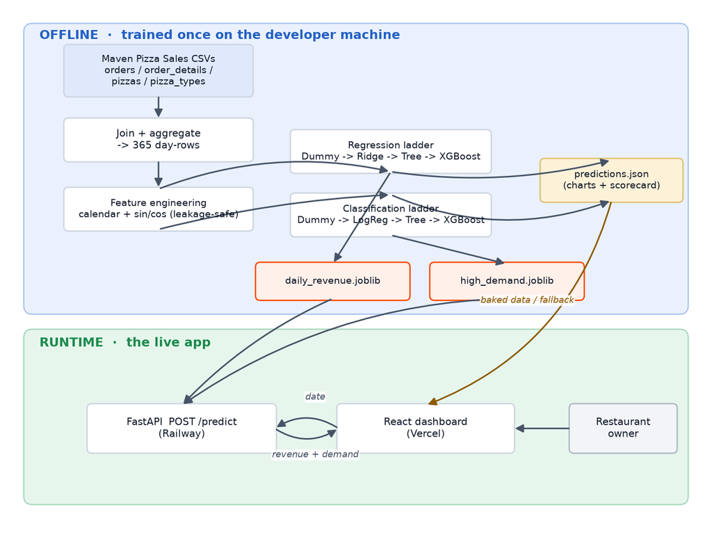

**Train once, offline → serve a saved model.** The app loads the trained model and predicts; it never re-trains while running.

## How we kept it honest

- Predict from the **date only** — no peeking at the future (no data leakage).
- Split the year **in time order**: train on Jan–Sep, test on Nov–Dec.
- Compare a full **ladder** of models against a simple baseline — and **keep the baseline in the table**.
- Report **cross-validation** as the fair metric, because a single year means the test months are calendar positions the model never saw.

## Finding 1 — the week has a strong rhythm

- **Weekends and Fridays** are reliably the busiest, highest-earning days.
- A mild seasonal lift in **summer and year-end**.
- This is the **most dependable signal** in the data.

## Finding 2 — busy days *can* be predicted

- From the calendar alone, the model flags **high-demand days clearly better than guessing** (ROC-AUC ≈ 0.74).
- A useful, no-integration-needed **planning aid** for shift levels.
- A lesson in metrics: a “predict busy every day” dummy looks good on one score (F1) but is **no better than a coin flip** on the honest one (AUC).

## Finding 3 — exact revenue is hard

- Day-to-day revenue swings are large; one year of data caps accuracy.
- The calendar gives a **ballpark**, not a precise dollar figure.
- This is a **data limitation, not a modelling mistake** — and it points to the fix.

## Recommendations

1. **Staff and stock to the weekly pattern** — heaviest Fri–Sun.
2. **Use the busy-day forecast** for shift planning.
3. **Invest in more data** — more years, plus promotions, weather, and events — to make revenue forecasting precise.

## Thank you

- **Live dashboard & predictor**, reproducible **analysis report**, and a public repo.
- Built with an AI-assisted workflow — every part verified and explainable.

*github.com/popovskik/IMB-Sales-Prediction-Project*